# Лабораторная работа No 5.

Тагиев Б. А.

Российский университет дружбы народов, Москва, Россия

7 октября 2023

## Цель работы

Изучение механизмов изменения идентификаторов, применения SetUID- и Sticky-битов. Получение практических навыков работы в консоли с дополнительными атрибутами. Рассмотрение работы механизма смены идентификатора процессов пользователей, а также влияние бита Sticky на запись и удаление файлов.

# Выполнение лабораторной работы

## SetUID бит

1. Из-под пользователя `guest` создадим файл `simpleid.c`

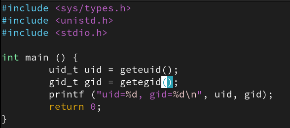

Исходный код файла simpleid.c

## SetUID бит

2. Скомпилируем, запустим и сравним результат с выводом команды `id`. User ID и Group ID совпадают.

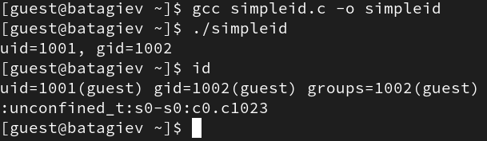

Результат

## SetUID бит

3. Перепишем программу, чтобы она возвращала нам `e_uid`/`e_gid` и действительный `uid`/`gid`. `getgid` возвращает действительный идентификатор группы текущего процесса. `getegid` возвращает эффективный идентификатор группы текущего процесса. Действительный идентификатор соответствует идентификатору вызывающего процесса. Эффективный идентификатор соответствует биту `setuid` на исполняемом файле.

[figure not shown]

Измененный исходный код программы simpleid.c

## SetUID бит

4. Поменяем пользователя-обладателя исполняемого файла и добавить бит `setuid`.

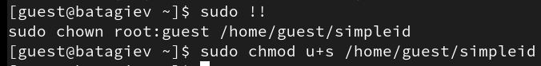

Изменение прав

## SetUID бит

5. Проверим изменения.

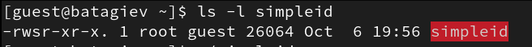

ls -l

## SetUID бит

6. Запустим исполняемый файл.

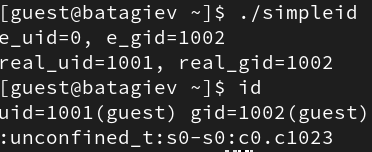

Результат

## SetUID бит

7. Проведем те же манипуляции над файлов, но теперь для группы.

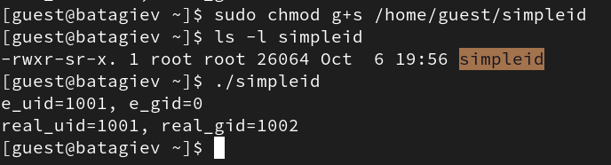

Результат

## SetUID бит

8. Создадим программу `readfile.c`

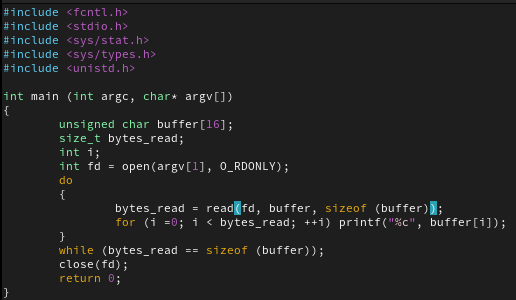

Исходный код файла readfile.c

## SetUID бит

9. Изменим права для файла `readfile.c`. Проверим изменения.

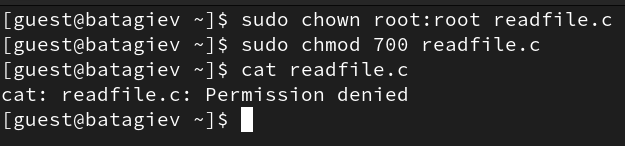

Измение прав файла readfile.c

## SetUID бит

10. Сменим владельца файла `readfile`, а также добавим `setuid` бит.

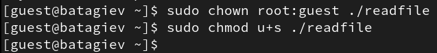

владелец и setuid бит

## SetUID бит

11. Проверим чтения разных файлов. Например `readfile.c` и `/etc/shadow`.

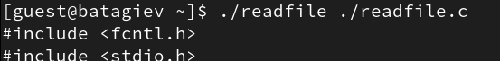

readfile.c

## SetUID бит

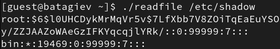

/etc/shadow

## Sticky бит

1. Проверим установлен ли атрибут Sticky на директорию `/tmp`.

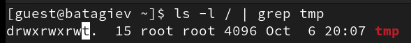

/tmp

## Sticky бит

2. Создадим файл `/tmp/file01.txt`. Добавим для остальных пользователей права на чтение и запись.

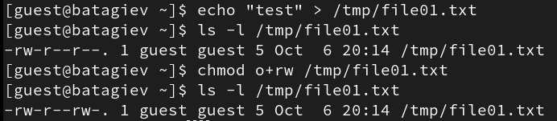

/tmp/file01.txt

## Sticky бит

3. Попробуем прочитать содержимое файла от пользователя `guest2`.

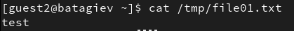

guest2

## Sticky бит

4. Допишем в конец файла новый текст.

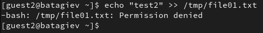

guest2

## Sticky бит

5. А также удалим этот файл.

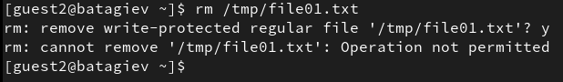

guest2

## Sticky бит

6. Удалим sticky бит директории `/tmp`.

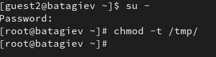

/tmp

## Sticky бит

7. Повторим предыдущие действия по изменению файла.

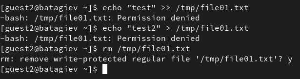

/tmp

## Выводы

В результате выполнения работы я выполнил цели работы.